# Hashing

Hashing adalah teknik yang digunakan dalam struktur data yang secara efisien menyimpan dan mengambil data dengan cara yang memungkinkan akses cepat.

- Hashing melibatkan pemetaan data ke indeks tertentu dalam Hash Table (array item) menggunakan fungsi hash . Ini memungkinkan pengambilan informasi yang cepat berdasarkan kuncinya.
- Keunggulan hashing adalah kita dapat melakukan ketiga operasi (pencarian, penyisipan, dan penghapusan) dalam waktu O(1) rata-rata.
- Hashing terutama digunakan untuk mengimplementasikan sekumpulan item yang berbeda (hanya kunci) dan kamus (pasangan kunci-nilai).

Berikut contoh hashing menggunakan metode modulo. Fungsi hash H(x) = x % 10mengubah bilangan besar apa pun menjadi nilai yang lebih kecil antara 0 dan 9.

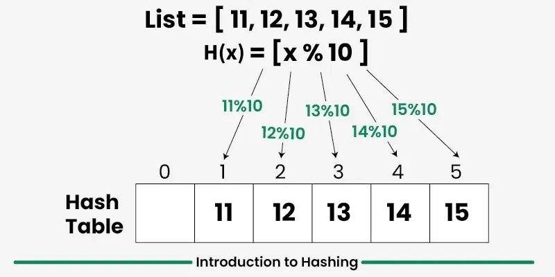

## Gambaran Umum Struktur Data Hash Table

- salah satu struktur data yang paling banyak digunakan setelah array.
- Pada dasarnya, ia mendukung pencarian, penyisipan, dan penghapusan dalam waktu O(1) rata-rata, yang lebih efisien daripada struktur data populer lainnya seperti array, Linked List, dan Self Balancing BST .
- Kami menggunakan hashing untuk kamus, penghitungan frekuensi, memelihara data untuk akses cepat berdasarkan kunci, dll.
- Aplikasi di dunia nyata meliputi pengindeksan basis data, kriptografi, cache, tabel simbol, dan kamus.
- Pada dasarnya ada dua bentuk hash yang umum diimplementasikan dalam bahasa pemrograman.

```
Hash Set : Kumpulan kunci unik (Diimplementasikan sebagai Set di Python , Set di JavaScript , unordered_set di C++ dan HashSet di Java ).
Hash Map : Kumpulan pasangan kunci-nilai dengan kunci yang unik (Diimplementasikan sebagai dictionary di Python, Map di JavaScript , unordered_map di C++ dan HashMap di Java ).
```

- Kita perlu mempertahankan data yang sudah diurutkan bersamaan dengan operasi pencarian, penyisipan, dan penghapusan. Dalam hal ini, kita menggunakan BST (Binary Search Tree) yang seimbang secara otomatis.
- Ketika string digunakan sebagai kunci dan kita membutuhkan operasi seperti pencarian awalan (prefix search) bersamaan dengan pencarian, penyisipan (insert), dan penghapusan (delete), kita menggunakan trie dalam kasus-kasus ini.
- Ketika kita membutuhkan operasi seperti pembulatan ke bawah dan ke atas, serta pencarian, penyisipan, dan/atau penghapusan, kita menggunakan BST Penyeimbang Mandiri (Self Balancing BST) dalam kasus-kasus ini.

## Komponen Hashing

Secara garis besar, hashing terdiri dari tiga komponen:

1. Key: Key dapat berupa string atau bilangan bulat apa pun yang dimasukkan sebagai input ke dalam fungsi hash, yaitu teknik yang menentukan indeks atau lokasi penyimpanan suatu item dalam struktur data.
2. Hash Function: Menerima Key masukan dan mengembalikan indeks elemen dalam sebuah array yang disebut Hash Table. Indeks tersebut dikenal sebagai indeks hash .
3. Hash Table: Hash Table biasanya berupa array berisi daftar. Tabel ini menyimpan nilai yang sesuai dengan kunci. Hash menyimpan data secara asosiatif dalam sebuah array di mana setiap nilai data memiliki indeks uniknya sendiri.

[figure not shown]

## Cara kerja Hashing

Misalkan kita memiliki sekumpulan string {"ab", "cd", "efg"} dan kita ingin menyimpannya dalam sebuah tabel.

- Langkah 1: Kita tahu bahwa fungsi hash (yang merupakan suatu rumus matematika) digunakan untuk menghitung nilai hash yang berfungsi sebagai indeks struktur data tempat nilai tersebut akan disimpan.
- Langkah 2: Jadi, mari kita tetapkan
  - “a” = 1,
  - “b”=2, .. dan seterusnya, untuk semua karakter alfabet.
- Langkah 3: Oleh karena itu, nilai numerik dengan penjumlahan semua karakter dari string adalah:

```
- “ab” = 1 + 2 = 3,
- “cd” = 3 + 4 = 7 ,
- “efg” = 5 + 6 + 7 = 18
```

- Langkah 4: Sekarang, anggaplah kita memiliki tabel berukuran 7 untuk menyimpan string-string ini. Fungsi hash yang digunakan di sini adalah jumlah karakter dalam key mod ukuran tabel . Kita dapat menghitung lokasi string dalam array dengan mengambil sum(string) mod 7 .
- Langkah 5: Jadi kita akan menyimpan
  - “ab” dalam 3 mod 7 = 3,
  - “cd” dalam 7 mod 7 = 0, dan
  - “efg” dalam 18 mod 7 = 4.

[figure not shown]

Teknik di atas memungkinkan kita untuk menghitung lokasi string tertentu dengan menggunakan fungsi hash sederhana dan dengan cepat menemukan nilai yang tersimpan di lokasi tersebut. Oleh karena itu, ide hashing tampaknya merupakan cara yang bagus untuk menyimpan pasangan (kunci, nilai) data dalam sebuah tabel.

## Teknik Penyelesaian Collisions

Dalam hashing , fungsi hash digunakan untuk menghasilkan nilai hash. Nilai hash tersebut digunakan untuk membuat indeks bagi kunci-kunci dalam tabel hash. Fungsi hash dapat mengembalikan nilai hash yang sama untuk dua kunci atau lebih. Ketika dua kunci atau lebih memiliki nilai hash yang sama, terjadilah tabrakan (collision ). Untuk menangani tabrakan ini, kita menggunakan Teknik Resolusi Tabrakan (Collision Resolution Techniques )

[figure not shown]

### Teknik Penyelesaian Collisions

Pada dasarnya ada dua metode untuk menangani tabrakan:

1. Separate Chaining

Open Addressina

[figure not shown]

#### 1) Separate Chaining

Membuat setiap sel tabel hash menunjuk ke daftar tertaut (linked list) dari catatan yang memiliki nilai fungsi hash yang sama. Chaining itu sederhana tetapi membutuhkan memori tambahan di luar tabel.

Contoh : Kita diberikan sebuah fungsi hash dan kita harus memasukkan beberapa elemen ke dalam tabel hash menggunakan metode separate chaining untuk teknik resolusi tabrakan (collision resolution).

[output not shown]

[figure not shown]

[figure not shown]

[figure not shown]

[figure not shown]

[figure not shown]

#### 2) Open Addressing

semua elemen disimpan dalam tabel hash itu sendiri. Setiap entri tabel berisi sebuah record atau NIL. Saat mencari suatu elemen, kita memeriksa slot tabel satu per satu hingga elemen yang diinginkan ditemukan atau jelas bahwa elemen tersebut tidak ada dalam tabel.

2.a) Linear Probing

Dalam pencarian linier, tabel hash dicari secara berurutan yang dimulai dari lokasi asli hash tersebut. Jika lokasi yang kita dapatkan sudah ditempati, maka kita periksa lokasi berikutnya.

```
ALGORITMA:
1. Hitung kunci hash. Yaitu kunci = data % ukuran
2. Periksa, apakah hashTable[key] kosong
    simpan nilai secara langsung dengan hashTable[key] = data
3. Jika indeks hash sudah memiliki nilai, maka
    Periksa indeks berikutnya menggunakan kunci = (kunci+1) % ukuran
4. Periksa, jika indeks berikutnya tersedia hashTable[key] maka simpan nilainya. Jika tidak, coba indeks berikutnya.
5. Lakukan proses di atas sampai kita menemukan tempatnya.
```

2.b) Quadratic Probing Probing kuadratik adalah skema pengalamatan terbuka dalam pemrograman komputer untuk menyelesaikan tabrakan hash dalam tabel hash. Probing kuadratik beroperasi dengan mengambil indeks hash asli dan menambahkan nilai-nilai berurutan dari polinomial kuadratik sembarang hingga ditemukan slot yang kosong.

Contoh urutan yang menggunakan probing kuadratik adalah:

```
H + 1^2 , H + 2^2 , H + 3^2 , H + 4^2 ...................... H + k^2
```

Metode ini juga dikenal sebagai metode mid-square karena dalam metode ini kita mencari probe (slot) ke -i pada iterasi ke-i dan nilai i = 0, 1, . . . n – 1. Kita selalu mulai dari lokasi hash asli. Jika lokasi tersebut terisi, maka kita periksa slot lainnya.

Misalkan hash(x) adalah indeks slot yang dihitung menggunakan fungsi hash dan n adalah ukuran tabel hash.

```
Jika slot hash(x) % n penuh, maka kita coba (hash(x) + 1^2 ) % n.
Jika (hash(x) + 1^2 ) % n juga penuh, maka kita coba (hash(x) + 2^2 ) % n.
Jika (hash(x) + 2^2 ) % n juga penuh, maka kita coba (hash(x) + 3^2 ) % n.
Proses ini akan diulang untuk semua nilai i sampai ditemukan slot kosong.
```